# WeRateDogs: Twitter Data Analysis

- *Suraj Singh Shahi*

After going through the whole wrangling process which was challenging yet thrilling, sometimes a little bit frustrating but all in all really challenging and fruitful. As I am here with insightful analysis of the data we just cleaned and analysed. The main focus of the WeRateDogs Twitter account is to show the world how cute dogs are will all their personality and charm and no dog is imperfect that is why the Twitter account always gives more than 10 out of 10 to the humans best friends.

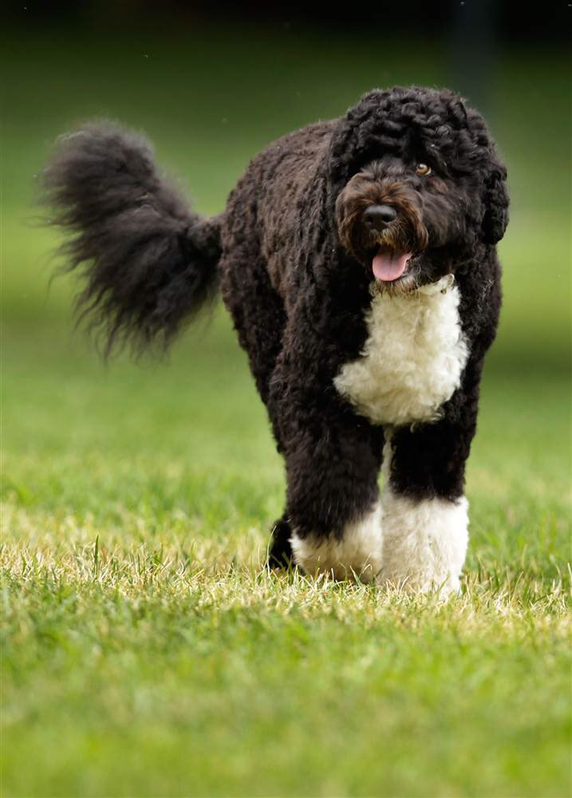

After seeing these lovely, majestic friends, I was curious which breed is the most popular on the account. After running few lines of code, we find this result:

### 10 Most popular breed of dogs -

'Golden Retriever', 'Labrador Retriever', 'Pembroke', 'Chihuahua','Pug', 'Toy Poodle', 'Chow', 'Samoyed', 'Pomeranian','Malamute'.

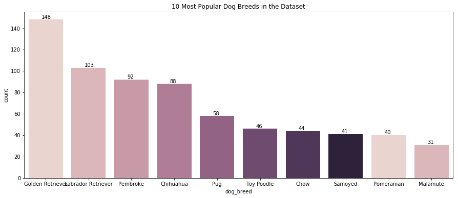

We also wanted to know what breed of dogs people like the most.

### 10 most favorited breed of dogs -

'Golden Retriever', 'Labrador Retriever', 'Pembroke', 'Chihuahua', 'Samoyed', 'French Bulldog', 'Chow', 'Pug', 'Malamute', 'Cocker Spaniel'

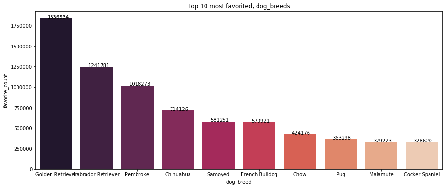

I also wanted to see what breeds of dogs are most shared or retweeted. Here is what we fond.

### 10 most retweeted dog breeds -

'Golden Retriever', 'Labrador Retriever', 'Pembroke', 'Chihuahua', 'Samoyed', 'French Bulldog', 'Chow', 'Pomeranian', 'Pug', 'Cocker Spaniel'

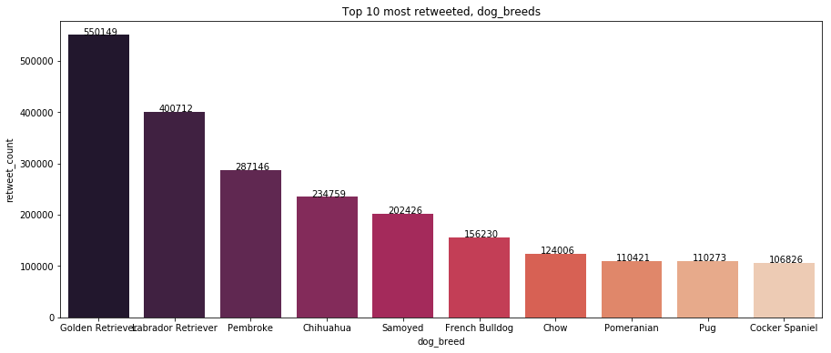

A lot of graph, I know, it is not as cute as the dogs itself, still they are really helpful in understanding about the popularity and love people give them. Since these were based purely on the bases of numbers the most popular dogs are also the most loved (favorited) and shared (retweeted).

We have found a very deep correlation between number of favorite and retweets. **0.91** correlation. It is evident by the graph -

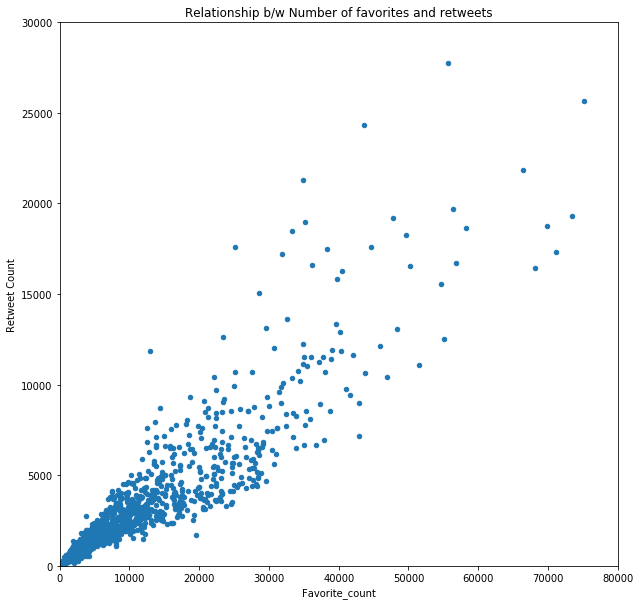

After this, let's see what names were the most popular amongst the furry friends.

### 10 most popular dog names -

'Cooper', 'Charlie', 'Lucy', 'Oliver', 'Tucker', 'Penny', 'Sadie', 'Winston', 'Daisy', 'Toby'.

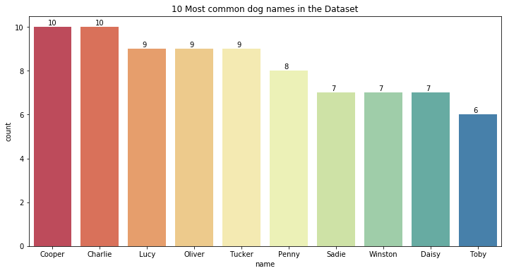

As we have discussed previously, The twitter account rate these dogs, since all dogs are beyond perfect we can expect them to get more than 10 out of 10.

Based on that analysis here are the best rated dog breeds.

### 10 best rated, dog breeds:

'Saluki', 'Briard', 'Tibetan Mastiff', 'Border Terrier', 'Silky Terrier', 'Standard Schnauzer', 'Irish Setter', 'Gordon Setter', 'Samoyed', 'Golden Retriever'

The rating values you can see in the graph is out of 100. So a value 118 shows, average rating of that breed is 118 our of 100.

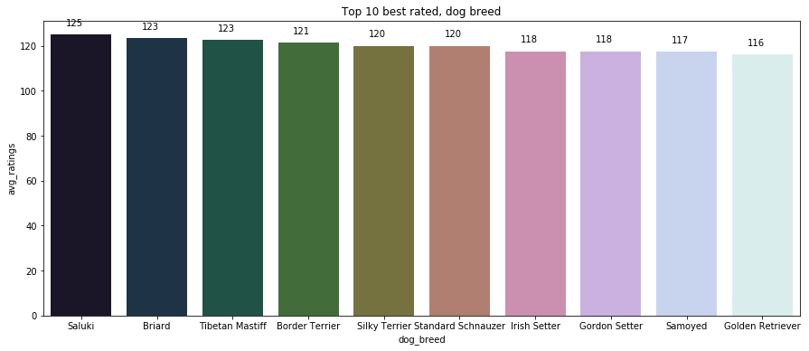

We have got some idea about the breeds and the names and how people react to them, lets see if the channel has also grown during this time. So WeRateDogs popularity overtime can be seen by the public engagement it will get in the form of number of favorites and retweets, the twitter account will get over time.

Here is the graph -

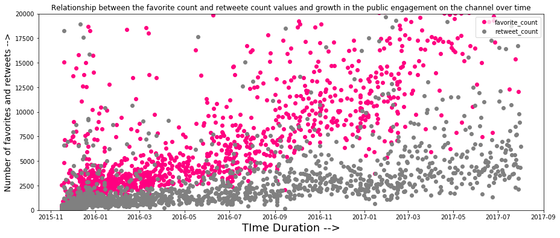

**We can see that 'WeRateDogs' twitter account, got more popular over time and there is also a very strong correlation between number of favorites and retweets.